# R4BD_Enron_project_V2

We do the same for the email received:

```r
status_email_subject <- df_message_status %>% distinct(date, recipient, status_recipient, subject, reference) %>%
  mutate(#count the number of email which contain at least one word in the list of each topic
    topic_meeting = if_else(str_detect(subject, topic_meeting), 1, 0),
    topic_business_process = if_else(str_detect(subject, topic_business_process), 1, 0),
    topic_core_business = if_else(str_detect(subject, topic_core_business), 1, 0),
    topic_enron_event = if_else(str_detect(subject, topic_enron_event), 1, 0),
    email_mark_to_market = if_else(str_detect(reference,"mark-to-market"), 1, 0),
    email_10K_report = if_else(str_detect(reference, "10-K"), 1, 0),
    email_losing_money = if_else(str_detect(reference, "losing money"), 1, 0),
    email_SEC_investigation = if_else(str_detect(reference, "SEC"), 1, 0),
    email_fear_feeling = if_else(str_detect(reference, "fears"), 1, 0),
    email_correction = if_else(str_detect(reference,"correction"),1,0),
    email_bankruptcy = if_else(str_detect(reference, "bankruptcy"), 1, 0),
    year = format(date, "%Y")) %>%
  #we focus on the worker which their status are know
  filter(!is.na(status_recipient)) %>%
  #compute the sum of each topics for each year studied
  group_by(year, status_recipient) %>%
  mutate(
    sum_topic_meeting = sum(topic_meeting),
    sum_topic_business_process = sum(topic_business_process),
    sum_topic_core_business = sum(topic_core_business),
    sum_topic_enron_event = sum(topic_enron_event),
    #for the email we use na.rm = TRUE to allow the sum to be done
    sum_email_mark_to_market = sum(email_mark_to_market, na.rm = TRUE),
    sum_email_10K_report = sum(email_10K_report, na.rm = TRUE),
    sum_email_losing_money = sum(email_losing_money, na.rm = TRUE),
    sum_email_SEC_investigation = sum(email_SEC_investigation, na.rm = TRUE),
    sum_email_fear_feeling = sum(email_fear_feeling, na.rm = TRUE),
    sum_email_correction = sum(email_correction, na.rm = TRUE),
    sum_email_bankruptcy = sum(email_bankruptcy, na.rm = TRUE)
    ) %>% ungroup() %>%
  #keep one line per year and month
  distinct(year, status_recipient, sum_topic_meeting, sum_topic_business_process, sum_topic_core_business, sum_topic_enron_event, sum_email_mark_to_market,
    sum_email_10K_report,
    sum_email_losing_money,
    sum_email_SEC_investigation,
    sum_email_fear_feeling,
    sum_email_correction,
    sum_email_bankruptcy)

#pivot the data frame
status_email_subject <- status_email_subject %>%
  pivot_longer(
    cols = 3:length(status_email_subject),
    names_to = "topic_email",
    values_to = "value")
```

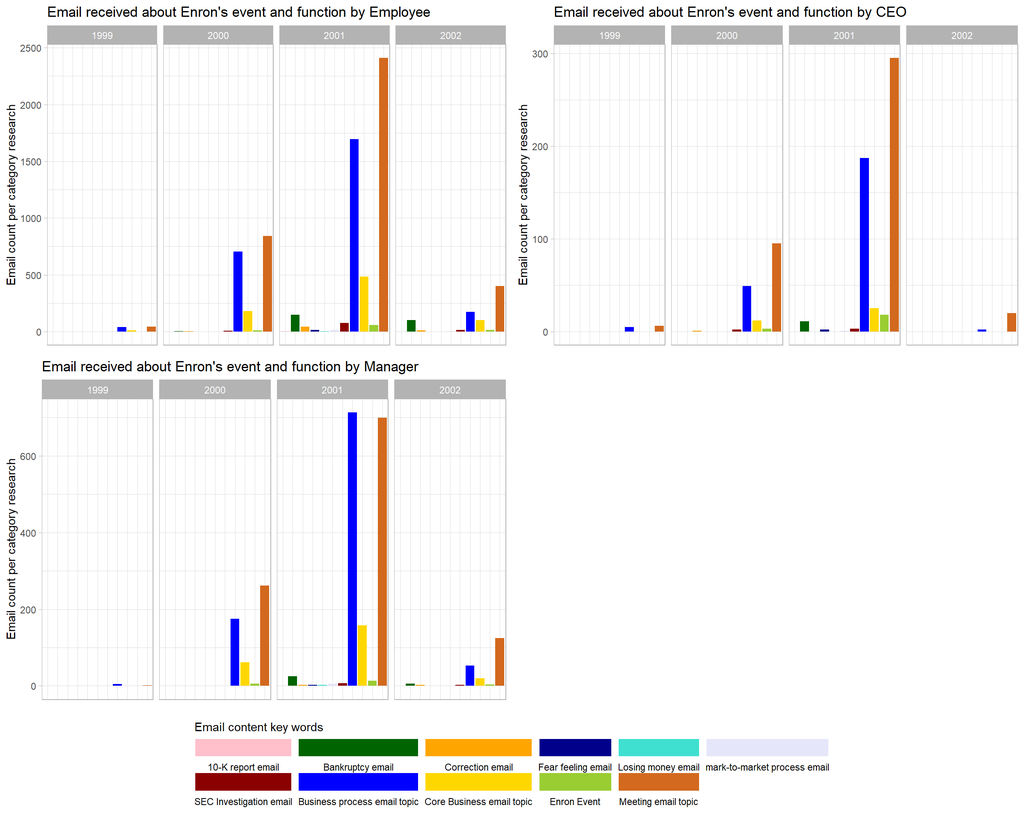

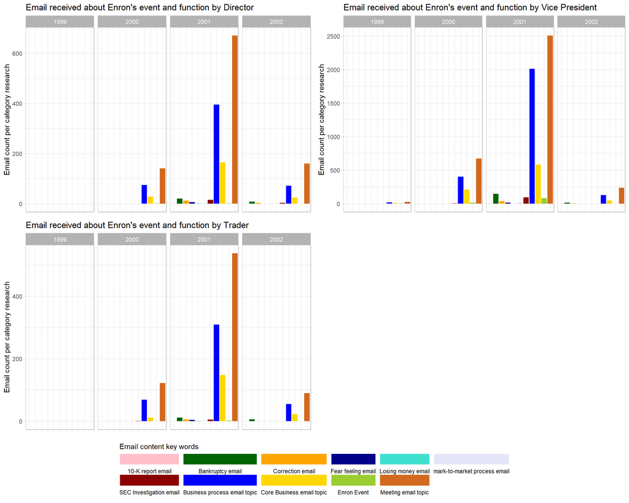

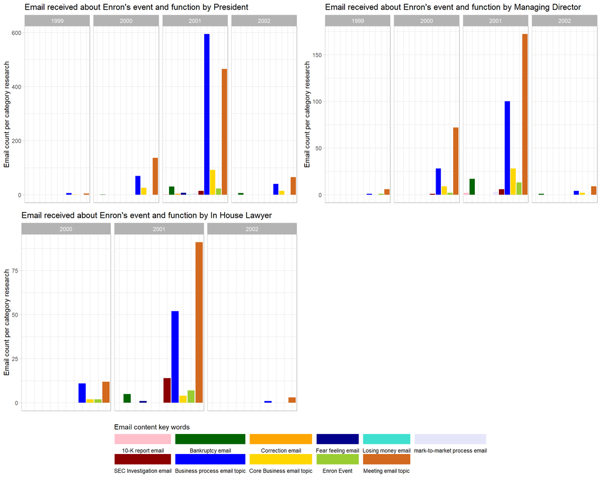

```r
status_list <- c("Employee", "CEO", "Manager", "Director", "Vice President", "Trader", "President", "Managing Director", "In House Lawyer")

#initiate the list to collect the plot
plot_list <- list()

#generating individual plot for each status
for(i in seq(status_list)){
  #assign the status to the variable
  status <- status_list[i]

  #the plot related to that status
  p <- status_email_subject %>% filter(status_recipient == status) %>%
         ggplot(aes(topic_email,value, fill = topic_email))+
         geom_bar(stat = "identity") +
       facet_grid(~year)+
         labs(fill = "Email content key words",
           title = paste("Email received about Enron's event and function by", status),
           y = "Email count per category research")+
         scale_fill_manual(values = topic_colors,
                    labels = topic_label)+
        theme(legend.text.position = "bottom",
           axis.title.x = element_blank(),
           axis.text.x = element_blank(),
               axis.ticks.x = element_blank())

  #append the plot list
  plot_list[[i]] <- p
}


#display the plot created
n <- length(plot_list)

#number of plot per layout
plot_per_section <- 3

#create plot layouts
for (i in seq(1, n, by=plot_per_section)){

  plot_on_the_page <- plot_list[i:min(i+2, n)]

  #extract the legend from the first plot on the layout
  legend <- get_legend(plot_on_the_page[[1]], nrow = 2)

  #remove the legend for all plot on the layout
  no_legend <- lapply(plot_on_the_page, function(p) p + theme(legend.position = "none"))

  #display 4 plots per layout
  grid_plot <- arrangeGrob(grobs = no_legend, ncol = 2)

  #combine together the 3 plot and one legend
  plots_with_legend <- arrangeGrob(
    grid_plot,
    legend,
    nrow = 2,
    #arrange the plot and the legend in the layout
    heights = unit.c(unit(1,"npc") - unit(7, "lines"), unit(7,"lines"))
  )

  #display everything together
  grid.newpage()
  grid.draw(plots_with_legend)

}
```

When we look at the email received we could see that:

- most of the time the email received are about meeting, except the manager and the president who received more email about the business process than other topics.
- some email are about the enron event in 2001 but that is less than the other topics.
- often it is in the email content we find the key word which are related to the enron event than in the email subject.
- less email have in topis core business compared to the business process especially for the head of the company and the trader suggested they are involved in the fraud.

```r
#global environment cleaning
rm(grid_plot, i, j, month_color, month_label, n, no_legend, p, p3, p4, plot_list, plot_on_the_page, plot_per_section, plots_with_legend, status, status_list,
   status_email_subject, adjacencyData_99, adjacencyData_00, adjacencyData_01, adjacencyData_02)
```

On the Enron scandal wikipedia page we find a list of person involved in the Enron scandal. We will research them in the data set to see if we can analyse the subject of the email they send as well as if they play a role in the Enron scandal. source: [wikipedia page about Enron timeline downfall](https://en.wikipedia.org/wiki/Enron_scandal#Timeline_of_downfall).

We find: - Kenneth Lay: he was the founder, chief executive officer, and the chairman of Enron and was heavily involved in Enron’s scandal.

- Jeffrey Skilling: he was the CEO of the company during the scandal and deeply involved in the fraud.
- Andrew Fastow: he was the chief financial officer and was fired shortly before the bankruptcy.
- Lea Fastow: she was the secretary of treasure in Enron and the wife of Andrew Fastow.
- Timothy Belden: he was the head of trading in Enron company.
- Vincent Kaminski: he work in Enron as the head of the quantitative modelling group.
- Jordan Mintz: he is a former managing director for the corporate tax at Enron
- Sherron Watkins: she was one of the vice-president in Enron
- Richard Causey: he was an accounting officer of Enron
- Greg Whalley: he was an enron executive.

From this list we add Jeff Dasovich who isn’t find in the wikipedia page but we find it to be the most active employee in the email sending. Maybe, he could be participate at some exchange related to the Enron’s events.

```r
#to find the person involved in the fiscal fraud we use str_detect to see if we can find them in the data set
#for example here for Vincent Kaminski
people_of_interest <- df_message_status%>% filter(str_detect(sender,"kaminski"))
```

First we look at the number of email send about those subjects

```r
#extract the worker who are interesting to follow and compute the number of email send by them
person_of_interest_send <- df_message_status %>% filter(str_detect(sender,"jeff.dasovich|andrew.baker|tim.belden|andrew.fastow|lfastow|vkaminski|jordan.mintz|jeff.skilling|sherron.watkins|richard.causey|greg.whalley")) %>%
  mutate(
  #identify the person who sent the email
  email_label_sender = case_when(
    sender == "jeff.dasovich@enron.com" ~ "Jeff Dasovich",
    sender == "kenneth.lay@enron.com" ~ "Kenneth Lay",
    sender == "jeff.skilling@enron.com" ~ "Jeffrey Skilling",
    sender == "andrew.baker@enron.com" ~ "Andrew Baker",
    sender == "tim.belden@enron.com" ~ "Timothy Belden",
    sender %in% c("lfastow@pop.pdq.net", "lfastow@pdq.net") ~ "Lea Fastow",
    sender == "andrew.fastow@enron.com" ~ "Andrew Fastow",
    sender %in% c("vkaminski@enron.com", "vkaminski@aol.com", "vkaminski@palm.net") ~ "Vincent Kaminski",
    sender == "jordan.mintz@enron.com" ~ "Jordan Mintz",
    sender == "sherron.watkins@enron.com" ~ "Sherron Watkins",
    sender == "richard.causey@enron.com" ~ "Richard Causey", #chief account officer wikipedia source
    sender == "greg.whalley@enron.com" ~ "Greg Whalley", #president and COO of Enron wholesale service
    .default = sender)) %>%
  #to compute the number of email sent in each topics by the person whose are directly involved in the Enron scandal
    group_by(date, email_label_sender) %>%
  mutate(#detect the pattern inside the subject or the email content
    topic_meeting = if_else(str_detect(subject, topic_meeting), 1, 0),
    topic_business_process = if_else(str_detect(subject, topic_business_process), 1, 0),
    topic_core_business = if_else(str_detect(subject, topic_core_business), 1, 0),
    topic_enron_event = if_else(str_detect(subject, topic_enron_event), 1, 0),
    email_mark_to_market = if_else(str_detect(reference,"mark-to-market"), 1, 0),
    email_10K_report = if_else(str_detect(reference, "10-K"), 1, 0),
    email_losing_money = if_else(str_detect(reference, "losing money"), 1, 0),
    email_SEC_investigation = if_else(str_detect(reference, "SEC"), 1, 0),
    email_fear_feeling = if_else(str_detect(reference, "fears"), 1, 0),
    email_correction = if_else(str_detect(reference,"correction"),1,0),
    email_bankruptcy = if_else(str_detect(reference, "bankruptcy"), 1, 0),
    year = format(date, "%Y"))%>% ungroup() %>%
  group_by(year, email_label_sender) %>%
  mutate(#compute the sum for each group
    sum_topic_meeting = sum(topic_meeting),
    sum_topic_business_process = sum(topic_business_process),
    sum_topic_core_business = sum(topic_core_business),
    sum_topic_enron_event = sum(topic_enron_event),
    #for the email we use na.rm = TRUE to allow the sum to be done
    sum_email_mark_to_market = sum(email_mark_to_market, na.rm = TRUE),
    sum_email_10K_report = sum(email_10K_report, na.rm = TRUE),
    sum_email_losing_money = sum(email_losing_money, na.rm = TRUE),
    sum_email_SEC_investigation = sum(email_SEC_investigation, na.rm = TRUE),
    sum_email_fear_feeling = sum(email_fear_feeling, na.rm = TRUE),
    sum_email_correction = sum(email_correction, na.rm = TRUE),
    sum_email_bankruptcy = sum(email_bankruptcy, na.rm = TRUE)) %>% ungroup() %>%
  #keep one line per year and month
  distinct(year, email_label_sender, sum_topic_meeting, sum_topic_business_process, sum_topic_core_business,sum_topic_enron_event,sum_email_mark_to_market,
    sum_email_10K_report,
    sum_email_losing_money,
    sum_email_SEC_investigation,
    sum_email_fear_feeling,
    sum_email_correction,
    sum_email_bankruptcy) %>%
  #filter to get only the date with email exchange for at least one of those topics
  filter((sum_topic_business_process != 0)|(sum_topic_meeting != 0)|(sum_topic_core_business !=0)|
           (sum_email_mark_to_market!=0)|(sum_email_10K_report != 0)|
           (sum_email_losing_money!=0)|(sum_email_SEC_investigation!=0)|(sum_email_fear_feeling!=0)|
           (sum_email_correction!=0)|(sum_email_bankruptcy!=0))

#pivot the table
person_of_interest_send <-person_of_interest_send %>%
  pivot_longer(
  cols = 3:length(person_of_interest_send),
  names_to = "topic_email",
  values_to = "value"
)
```